# Housing Project

9/22/21

#### Team Members: Tanvi Yende, Linda Mao, Dov Greenwood

## Reading in Cleaned Data & Completing Formatting as Necessary

```r
#reading in required libraries
library(ggplot2)
library(scales)
library(gridExtra)
library(dplyr)
library(tidyverse)
options(warn=-1)
```

```r
#reading in data
dat <- read.csv("data/finalData.csv")
head(dat)
```

|  | pid | address | value | buildings | year | land | living | good | style | model | grade | beds | baths | heatfuel | heattype | ac | nghd |
| --- | --- | --- | --- | --- | --- | --- | --- | --- | --- | --- | --- | --- | --- | --- | --- | --- | --- |
| 1 | 3 | 199 SOUTH END RD | 145670 | 1 | 1950 | 0.25 | 1475 | 73 | Cape Cod | Single Family | Above Average | 3 | 2.5 | Hot Water | Hot Water | no | 101 |
| 2 | 4 | 11 URIAH ST | 150710 | 1 | 1989 | 0.18 | 1792 | 82 | Colonial | Single Family | Average | 3 | 2.5 | Hot Water | Hot Water | yes | 101 |
| 3 | 5 | 181 SOUTH END RD | 115010 | 1 | 1945 | 0.36 | 864 | 73 | Ranch | Single Family | Average | 3 | 1.0 | FA/HW/ST | FA/HW/ST | no | 101 |
| 4 | 6 | 169 SOUTH END RD | 105280 | 1 | 1940 | 0.32 | 1040 | 63 | Bungalow | Single Family | Average | 3 | 1.0 | Steam | Steam | no | 101 |
| 5 | 7 | 173 SOUTH END RD | 129290 | 1 | 1986 | 0.35 | 1512 | 77 | Cape Cod | Single Family | Average | 5 | 2.0 | FA/HW/ST | FA/HW/ST | yes | 101 |
| 6 | 8 | 165 SOUTH END RD | 95060 | 1 | 1940 | 0.17 | 1080 | 63 | Cape Cod | Single Family | Average | 3 | 1.5 | FA/HW/ST | FA/HW/ST | no | 101 |

```r
#basic data cleaning
dat <- dat[dat$beds != "0",]
dat <- unique(dat)

#coercing ac variable to be a binary instead of yes/no format
dat$ac <- ifelse(dat$ac == 'yes', TRUE, FALSE)
```

## Explanation of Data Reconciliation

Data Reconciliation: There were multiple differences in our data resulting from our different approaches to wrangling the raw HTML data, which required reconciliation. Primarily, the differences resulted from different grep searches; these included comprehensiveness (e.g. whether we searched for the word “Ttl” as well as “Total”) and use of different categories for the same category (namely, “land model” versus “building model”). A more significant difference came in whether or not to include half bathrooms in the bathroom count or not, especially since two half bathrooms would some to one full bathroom in the raw sum, even though in reality two half bathrooms do not equate to one whole bathroom. We ultimately decided to include half bathrooms in the sum as we would lose significant data from excluding them.

Data Cleaning: After the data was reconciled, some cleaning was necessary. Some of the entries had extra whitespace before and after the actual data, which we removed using the trimws() function. In the specific case of the heating fuel column, identical options were sometimes labeled differently—namely, “Gas/Oil” and “Oil/Gas”—which we standardized by assigning both such values to “Gas/Oil.” Then, we examined each variable and if there were any glaring outliers. In the case of the “Percent Good” variable, only two properties exceeded 100% Good. However, upon examining the properties, we found that they were unusually nice (high value, many bedrooms, etc.), which warranted the very high value.

For style, we removed “Apt House,” which appeared to have been erroneously labeled with the model “Single Family.” In this project, we are only looking at true single family homes, and this apartment house would have skewed bedroom/bathroom numbers–thus, we deleted “Apt House” styles from the dataset. Other potentially disruptive styles, like “Inn,” had normal bedroom/bathroom values, so we decided to keep them.

## Exploratory Analysis

### Descriptions

```r
#creating decade function for the sake of exploratory analysis
floor_decade    = function(value){ return(value - value %% 10) }
```

```r
#Visualizing the type and size of data
str(dat)
```

```
## 'data.frame':    9134 obs. of  17 variables:
##  $ pid      : int  3 4 5 6 7 8 9 10 23 24 ...
##  $ address  : Factor w/ 9135 levels "1 BEACON AV",..: 2919 429 2573 2215 2356 2133 2040 1889 6511 395 ...
##  $ value    : int  145670 150710 115010 105280 129290 95060 95970 93520 123340 182280 ...
##  $ buildings: int  1 1 1 1 1 1 1 1 1 1 ...
##  $ year     : int  1950 1989 1945 1940 1986 1940 1930 1900 1940 1940 ...
##  $ land     : num  0.25 0.18 0.36 0.32 0.35 0.17 0.14 0.2 0.16 0.13 ...
##  $ living   : int  1475 1792 864 1040 1512 1080 1040 985 1484 2124 ...
##  $ good     : int  73 82 73 63 77 63 63 63 68 78 ...
##  $ style    : Factor w/ 13 levels "2 Family","Bungalow",..: 3 4 11 2 3 3 3 11 3 4 ...
##  $ model    : Factor w/ 1 level "Single Family": 1 1 1 1 1 1 1 1 1 1 ...
##  $ grade    : Factor w/ 16 levels "Above Average",..: 1 4 4 4 4 4 1 4 4 3 ...
##  $ beds     : int  3 3 3 3 5 3 2 1 2 3 ...
##  $ baths    : num  2.5 2.5 1 1 2 1.5 1 1 1.5 2 ...
##  $ heatfuel : Factor w/ 11 levels "Electr Basebrd",..: 7 7 2 11 2 2 2 2 5 3 ...
##  $ heattype : Factor w/ 11 levels "Electr Basebrd",..: 7 7 2 11 2 2 2 2 5 3 ...
##  $ ac       : logi  FALSE TRUE FALSE FALSE TRUE FALSE ...
##  $ nghd     : Factor w/ 34 levels "1000","101","1100",..: 2 2 2 2 2 2 2 2 2 2 ...
```

```r
#Finding descriptive information on value, our variable of interest
summary(dat$value)
```

```
##    Min. 1st Qu.  Median    Mean 3rd Qu.    Max.    NA's
##   27300   92890  119000  149882  160930 3037930       1
```

#### Explanation of Data Exploration & Analysis

Data Transformation: For land (in acres), there was an outlier at 16.91, when the median was 0.17. However, we did not remove it, as we performed a log transformation on this variable for our model, which brought the value significantly closer to the rest of the data. We also put log transformations on the variables living, land, and value because they were skewed.

We also checked for collinearity with good vs. grade, beds vs. baths, beds vs. living space, and baths vs. living space. For all of these comparisons except good vs. grade, the adjusted R-squareds were relatively low < 0.5, so we opted to keep both. For good vs. grade, the adjusted R-squared was high and significantly correlated, so we determined that we should try to keep good over grade because it was numeric.

How Strongly/Weakly Associated Are Certain Variables with Assessed Value:

Living, beds, baths, percent good, grade, land are all positively associated and appear to be strongly associated with assessed value. Year built appears to be weakly associated with assessed value, and it is unclear if it is positively or negatively associated.

Benefits & Drawbacks of Defining Beds and Baths as Numeric Data:

The benefit of defining beds and baths as numeric data is interpretability–people understand the number of beds and baths intuitively on a number scale. The drawbacks of defining them as numeric data is that the data doesn’t vary linearly with the dependent variable, log value, and it was very discrete data (in our model, we actually chose to define bed as a categorical variable).

### Explanatory Plots

#### Visualizing Assessed Value

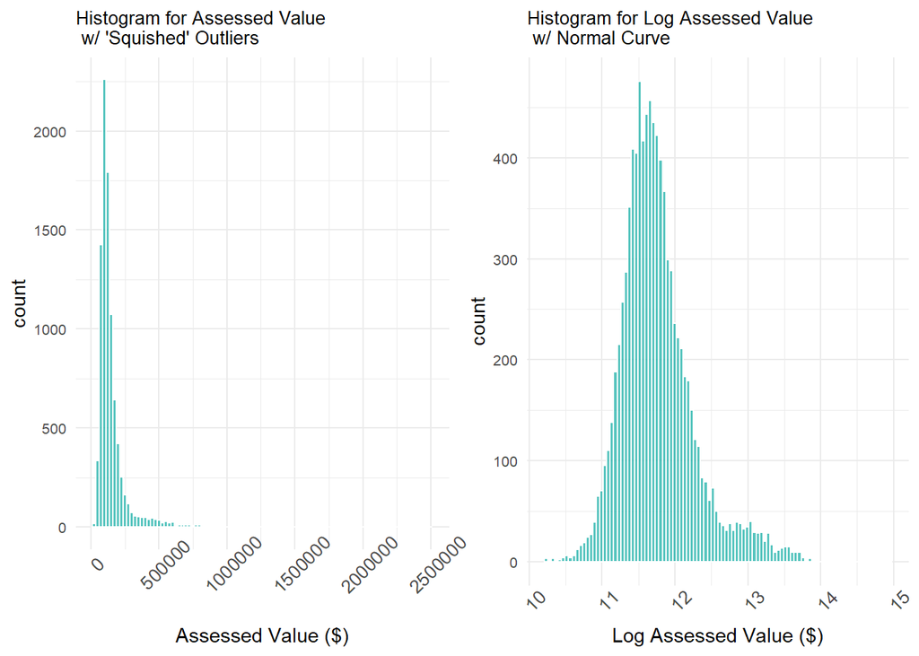

Assessed value is right-skewed and exponential, which will be an issue for a linear model. The log transformation shows that this transformation appropriately creates a normal distribution.

#### Visualizing Number of Beds

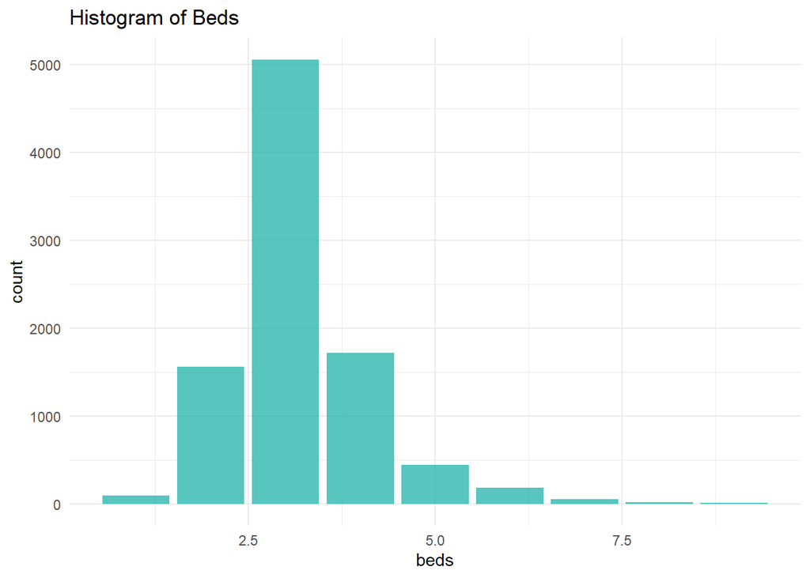

The distribution of beds appears to be right-skewed.

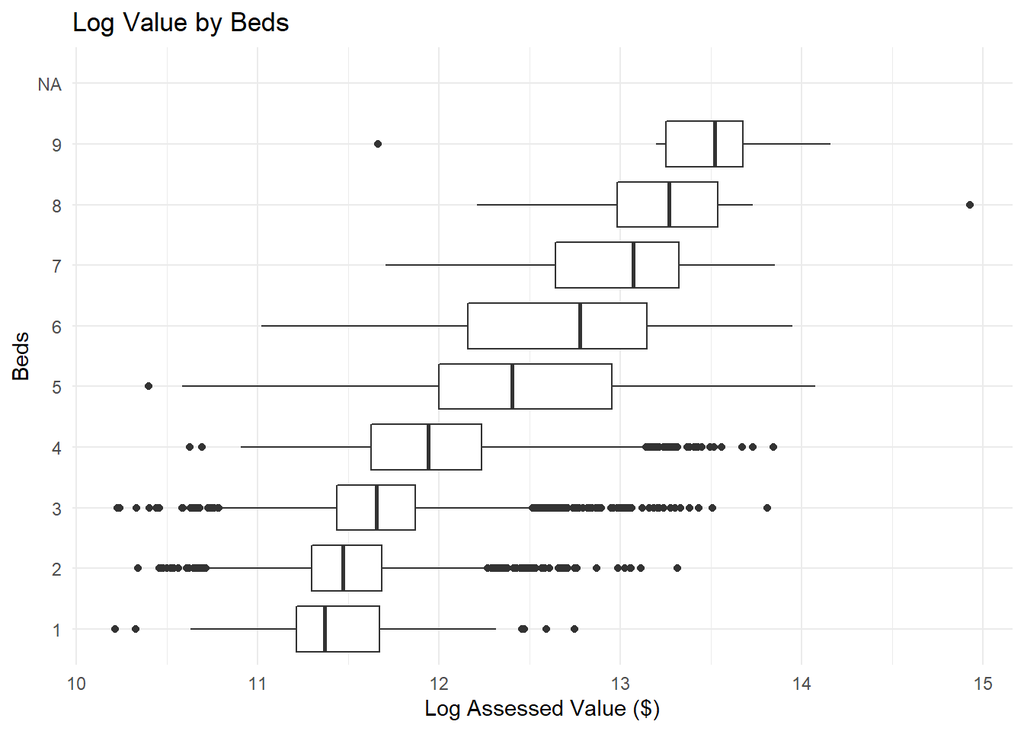

```r
p16
```

Because the relationship between log value and log beds still does not vary linearly, we will treat beds as a categorical variable.

#### Visualizing Land Variable

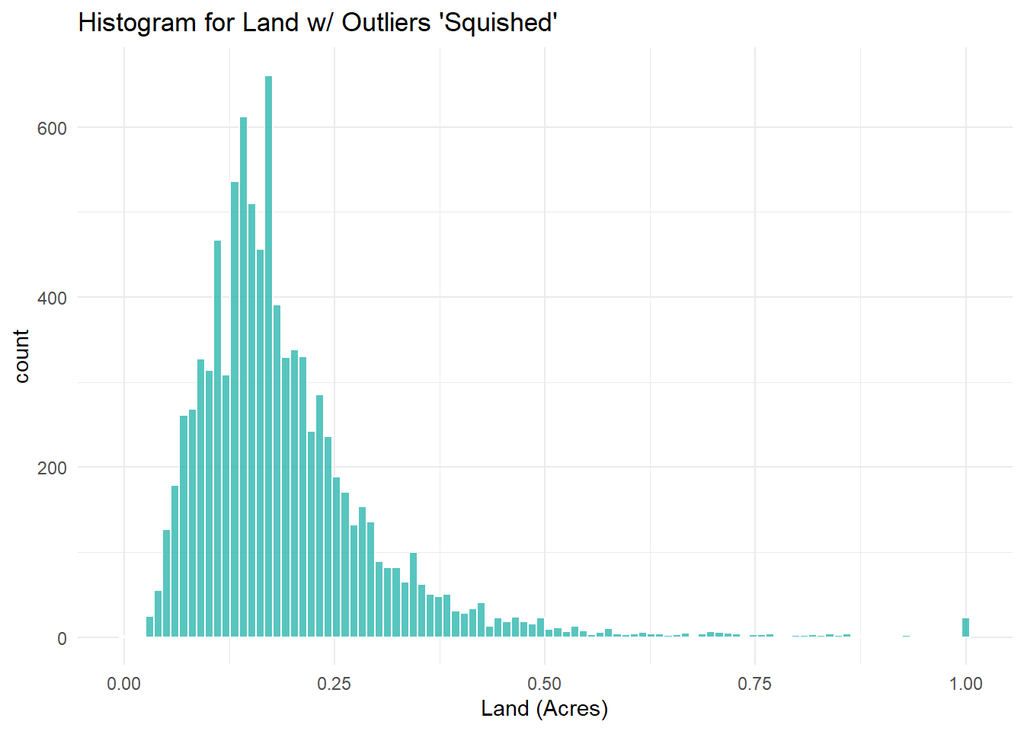

```r
p5
```

The histogram shows that the land variable appears to be right-skewed.

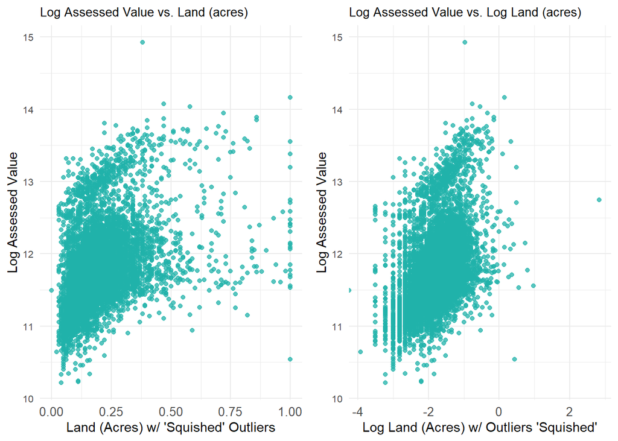

The relationship between log value and land appears exponential, but log value and log land vary more linearly. In our model, we will use log land for this reason.

#### Visualizing Living Area

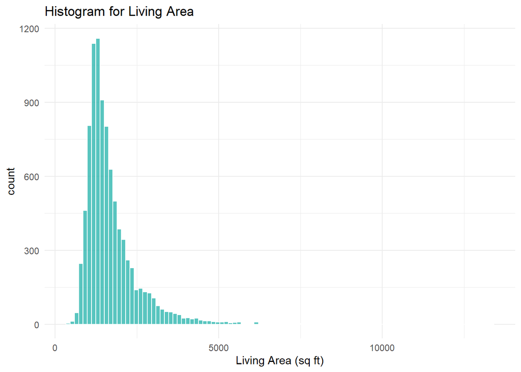

The histogram for living area shows that the variable is right-skewed.

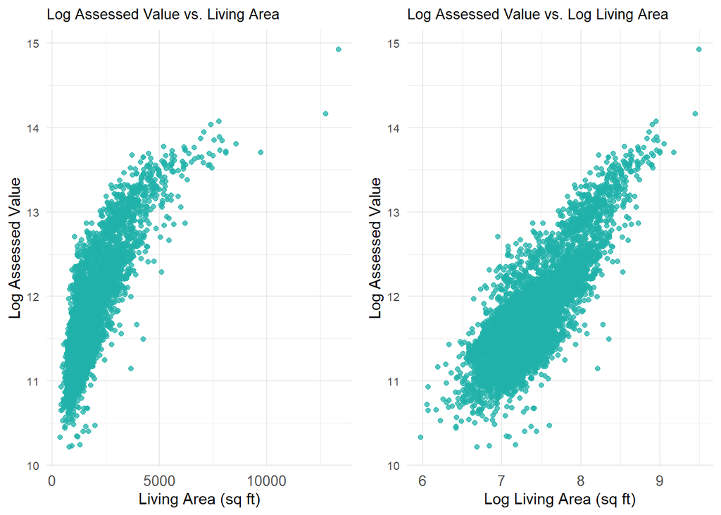

#### Visualizing AC Type

Note that we coerced ac to be a binary of either with or without ac

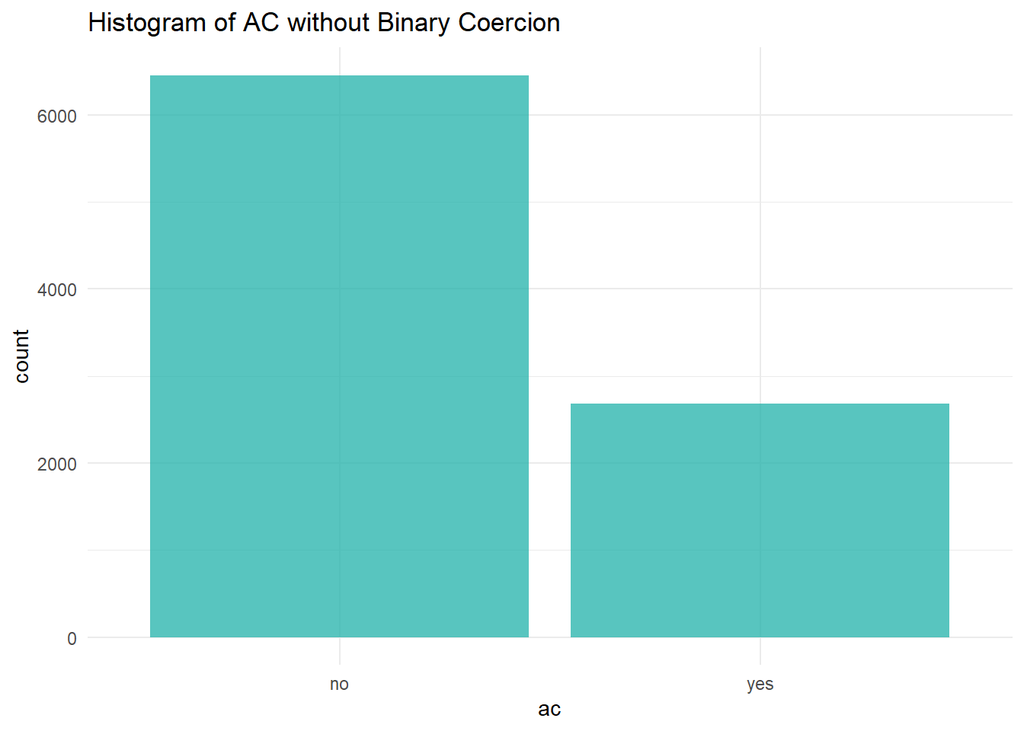

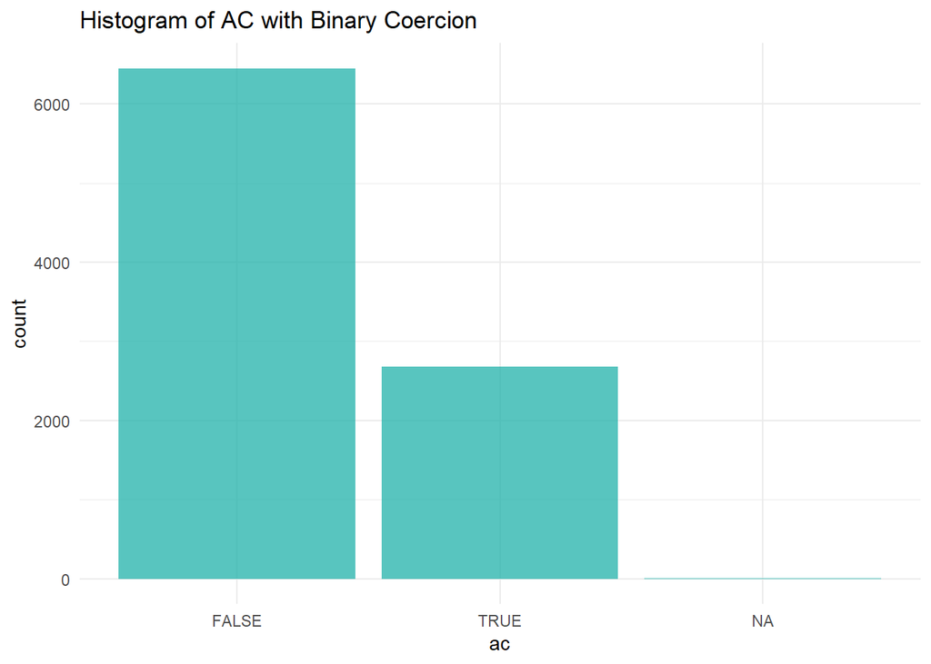

The distribution shows more houses don’t have ac than do.

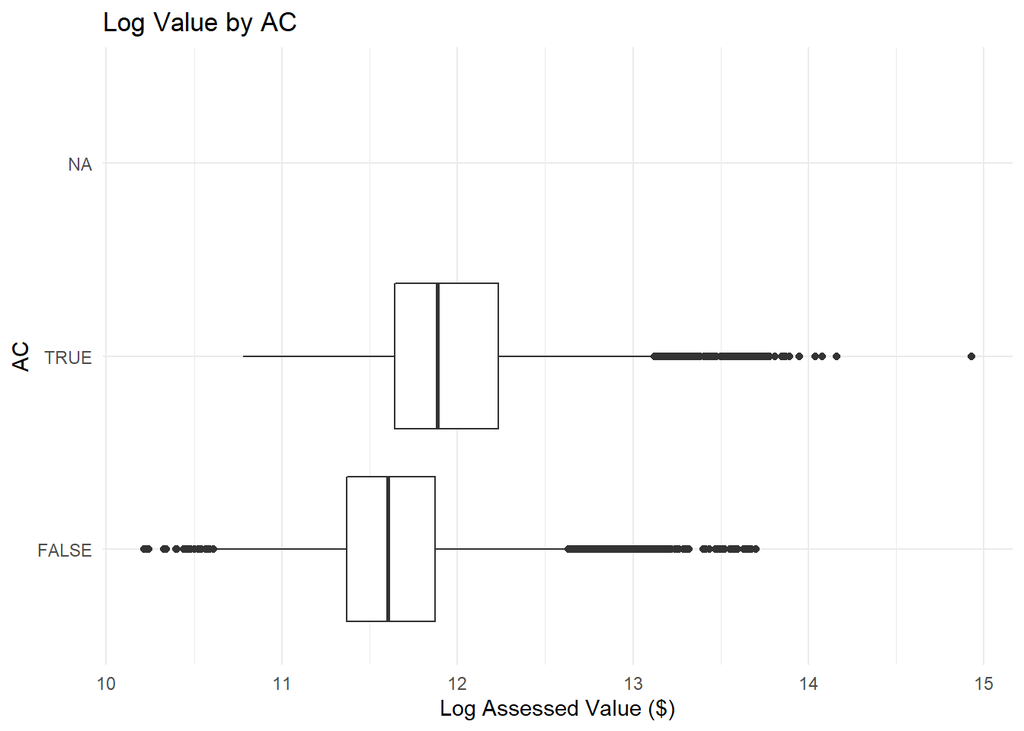

Homes with AC may have a higher value than those without, but this relationship is weak from this visualization.

#### Visualizing Percent Good

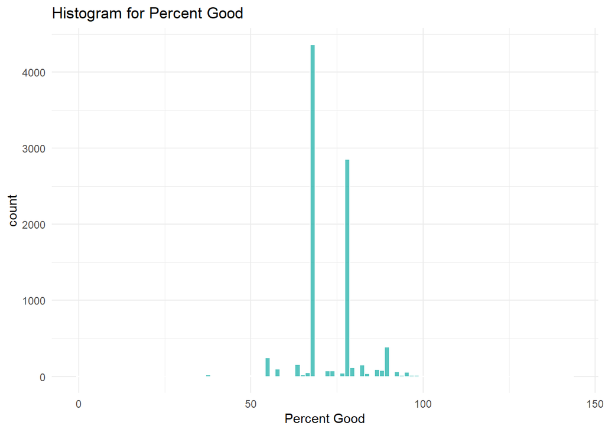

The distribution is not clear from the histogram.

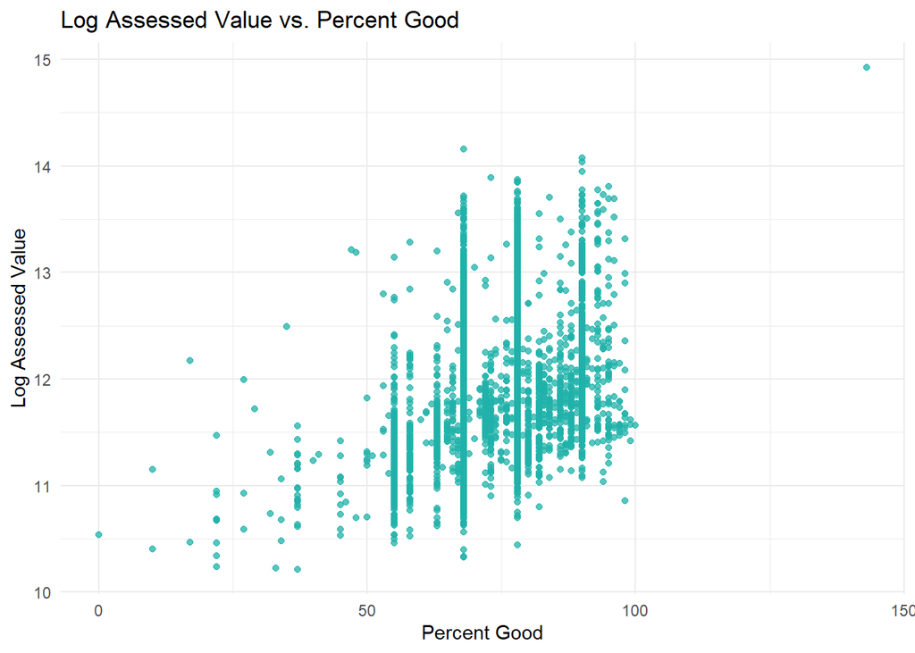

Percent good seems to vary linearly with log value.

#### Visualizing Year Variable

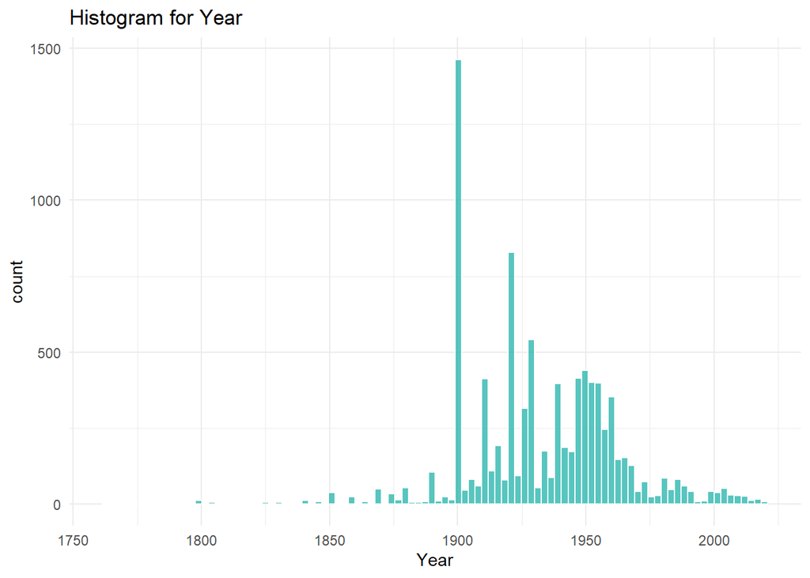

There seems to be many houses built in 1900, possibly indicating a data error or a large volume of houses built in 1900. We couldn’t resolve this question via historical research. There also seems to be a cluster of houses built around 1950.

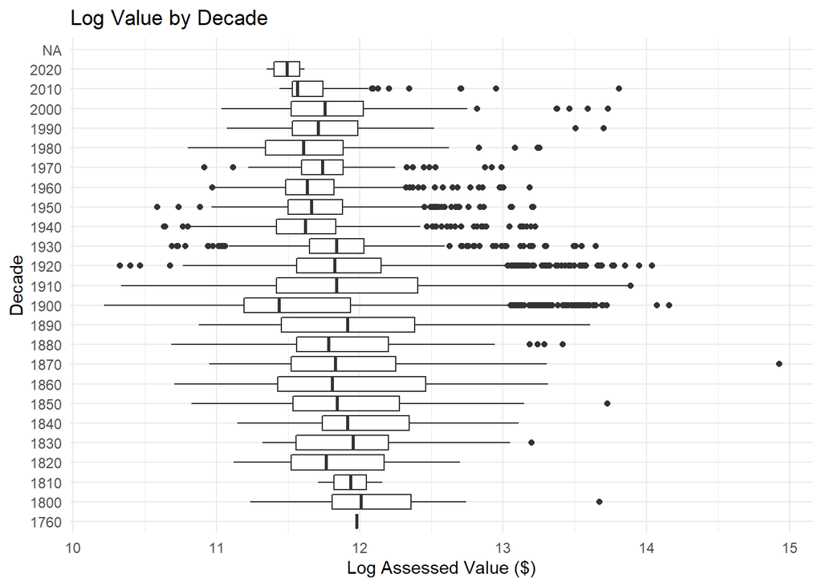

There doesn’t seem to be a clear relationship between year the house was built in and its assessed value.

#### Visualizing Baths

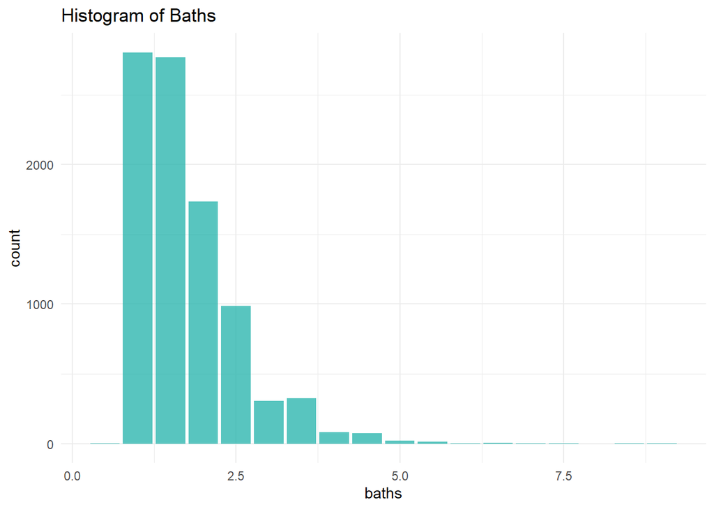

The distribution of baths appears to be right-skewed.

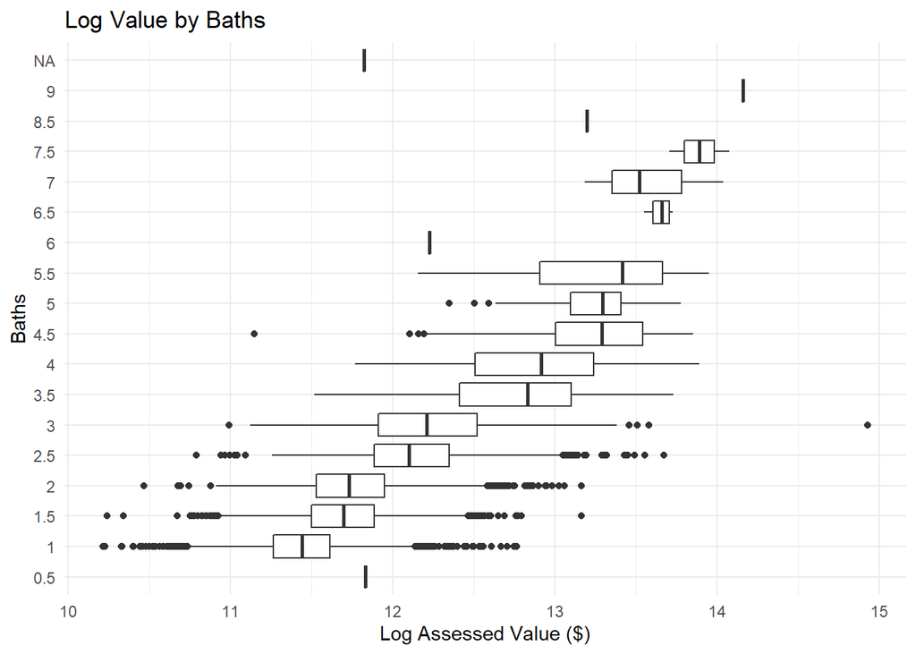

```r
p18
```

There appears to be a somewhat linear relationship between baths and log value. Upon testing in the model there was not a significant difference between treating baths numerically or categorically, so we kept it numeric to allow for half baths.

#### Visualizing Style

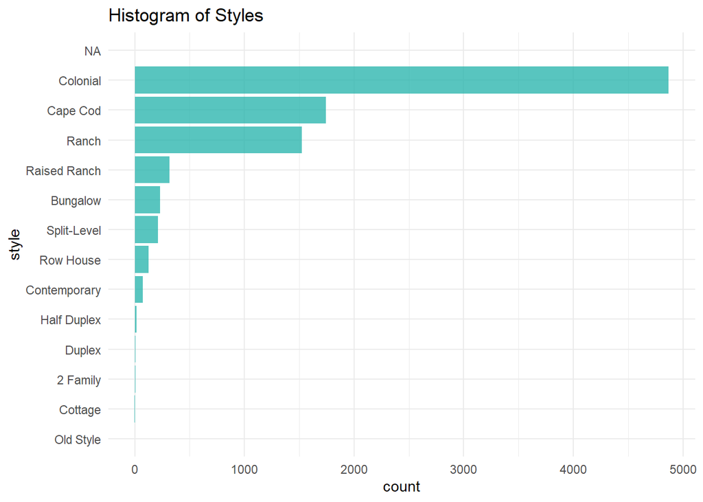

```r
dat$style <- reorder(as.factor(dat$style),as.factor(dat$style), FUN = length) #reordering levels so that they appear in order of frequency
p11 <- ggplot(data = dat, aes(style)) +
  geom_bar(fill="#20B2AA", alpha=0.75) +
  theme_minimal() +
  coord_flip() +
  labs(title = "Histogram of Styles")


p12 <- ggplot(data = dat, aes(x=style,y=log(value))) +
  geom_boxplot() +
  coord_flip() +
  labs(x="Style", title = "Log Value by Style", y="Log Assessed Value ($)")+
  theme_minimal()
```

Colonial is by far the most frequent style in the data set.

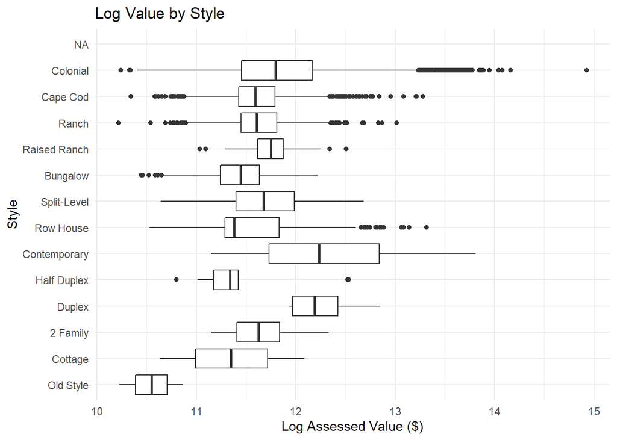

There doesn’t appear to be an easily interpretable relationship between style and log value from this plot.

#### Visualizing Grade

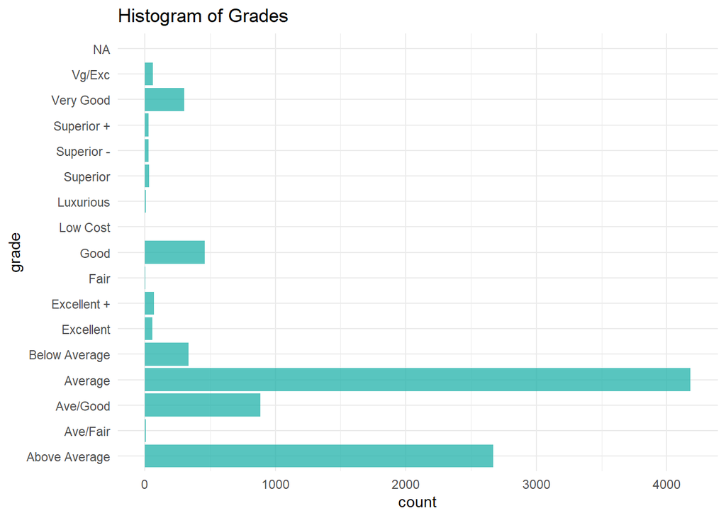

```r
p13
```

Most houses are given an average grade

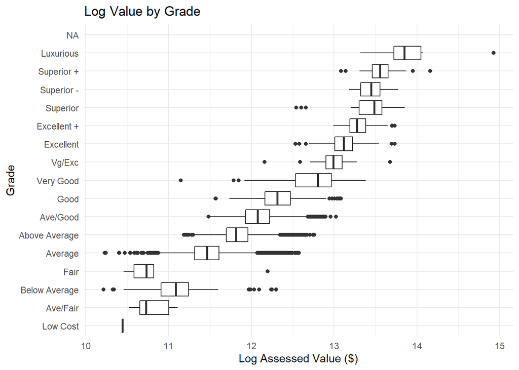

There is a predictable linear relationship between the grade and value of the houses in our data set.

#### Visualizing Heat Fuel

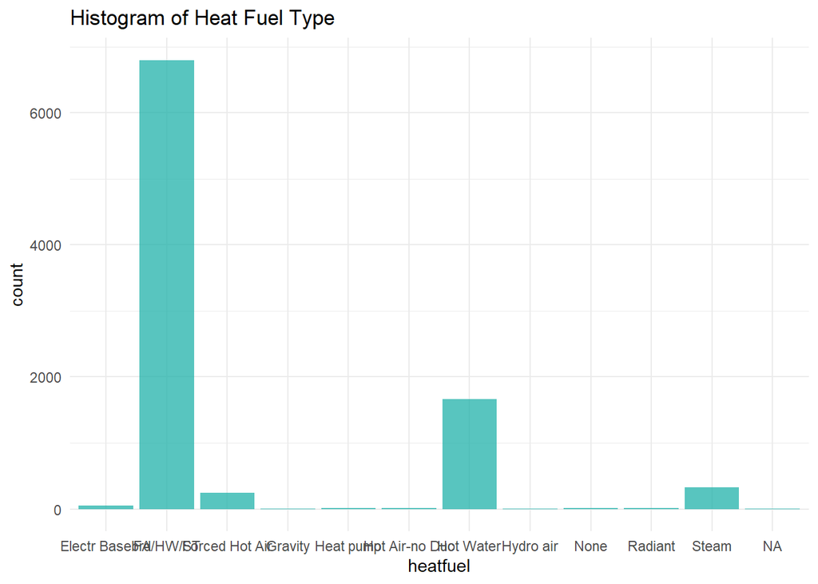

#### Visualizing Heat Type

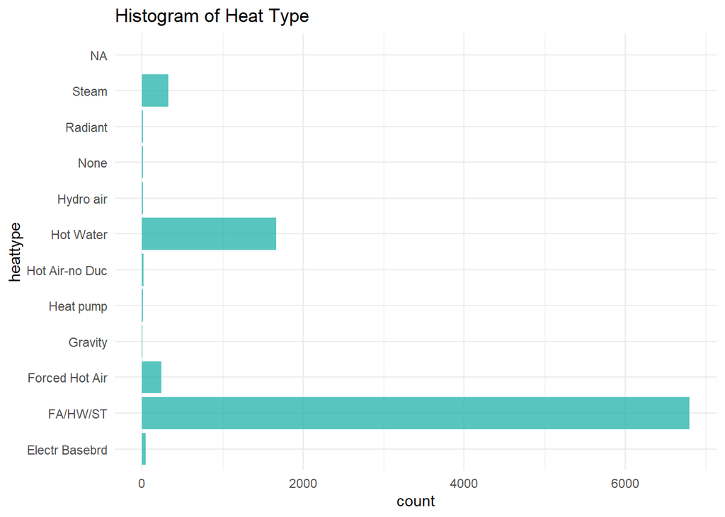

The histogram shows that most houses have FA/HW/ST heating. Research indicates that this probably stands for Forced Air/Hot Water/Steam.

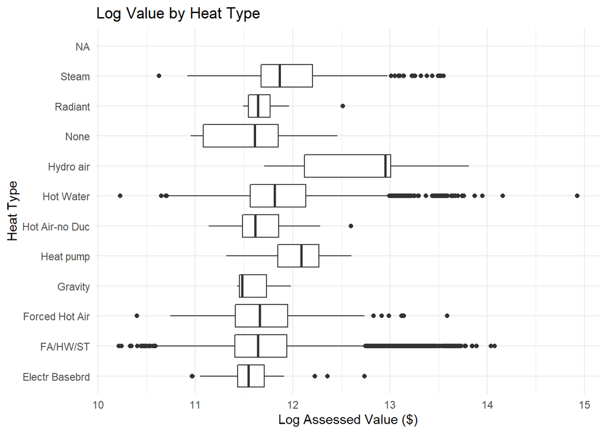

There doesn’t appear to be an obvious relationship between heat type and log value.

#### Visualizing Neighborhoods

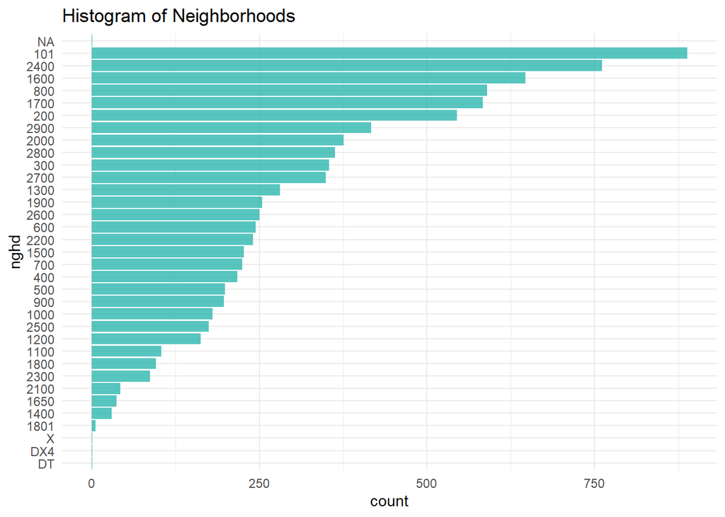

The most common neighborhood the houses are found in is labeled by code “0101”.

## Building the Statistical Model

We tested both forwards and backwards stepwise regression and chose to use backwards regression, as it resulted in better and more interpretable models. However, the two didn’t produce vastly different results.

### Building the Linear Model

```r
####-----------SETUP-----------####
set.seed(31415)
folds <- 10

# Remove extraneous data, set rownames to PID
data <- dat[, !(names(dat) %in% c('pid', 'buildings', 'model', 'address', 'grade', 'heatfuel'))]

# Remove outliers
data <- data[data$beds > 0,]
data <- data[data$baths > 0,]

# Formatting the data
data$style <- as.factor(trimws(data$style))
data$heattype <- as.factor(trimws(data$heattype))
data$nghd <- as.factor(trimws(data$nghd))
data$beds <- as.factor(data$beds)
#data$ac <- as.factor(data$ac)

# Remove rows that are now identical
data <- unique(data)

# From previous analysis, we find that the log of certain values gives greater linear correlation
# than the values themselves
data$value <- log(data$value)
data$land <- log(data$land)
data$living <- log(data$living)

# After performing the log, we need to remove 'Inf's that may have appeared
data <- filter(data, is.finite(data$land))


####-----------MAIN-----------####
# Randomize the order of checking the columns. Also ignore the value column, as it is the response
# variable, and add '' to ensure that the first loop will use all columns.
selected <- names(data)[sample(length(data))]
selected <- c('', selected[selected != 'value'])

prev.RMSE <- Inf

for(col in selected) {
  avg.RMSE <- 0

  fields <- selected[selected != col]
  sub.data <- data[c('value', fields)]

  print(fields)

  for(i in 1:folds) {
    row.order <- sample(nrow(data))
    train.rows <- sub.data[head(row.order, nrow(data)*0.8),]
    test.rows <- sub.data[tail(row.order, -nrow(data)*0.8),]

    # The test.rows DF sometimes gets an NA row for no apparent reason...
    test.rows <- filter(test.rows, !is.na(test.rows$value))

    curr.model <- suppressWarnings(lm(value ~ ., train.rows))

    # Fill out the factor levels that were not used during training
    curr.model$xlevels$heattype <- levels(data$heattype)
    curr.model$xlevels$style <- levels(data$style)
    curr.model$xlevels$nghd <- levels(data$nghd)
    curr.model$xlevels$beds <- levels(data$beds)
    #curr.model$xlevels$ac <- levels(data$ac)

    predictions <- predict.lm(curr.model, test.rows)
    avg.RMSE = avg.RMSE + sqrt(mean((test.rows$value - predictions)^2))
  }

  avg.RMSE <- avg.RMSE / folds

  print(paste('Average:', avg.RMSE))
  if(avg.RMSE < prev.RMSE) {
    selected <- fields
    prev.RMSE <- avg.RMSE
    print('Updated!')
  }
}
```

```
##  [1] "year"     "land"     "baths"    "style"    "ac"       "good"
##  [7] "living"   "nghd"     "heattype" "beds"
## [1] "Average: 0.108163363624453"
## [1] "Updated!"
## [1] "land"     "baths"    "style"    "ac"       "good"     "living"   "nghd"
## [8] "heattype" "beds"
## [1] "Average: 0.106663423646665"
## [1] "Updated!"
## [1] "baths"    "style"    "ac"       "good"     "living"   "nghd"     "heattype"
## [8] "beds"
## [1] "Average: 4.21678001351338"
## [1] "land"     "style"    "ac"       "good"     "living"   "nghd"     "heattype"
## [8] "beds"
## [1] "Average: 4.08485096354615"
## [1] "land"     "baths"    "ac"       "good"     "living"   "nghd"     "heattype"
```

[output cut: 16 more lines]

```r
print(paste('Final RMSE:', prev.RMSE))
```

```
## [1] "Final RMSE: 0.0983962067494233"
```

```r
print(selected)
```

```
## [1] "land"   "baths"  "ac"     "good"   "living" "nghd"   "beds"
```

```r
final.model <- lm(value ~ ., data[c('value', selected)])

summary(final.model)
```

```
##
## Call:
## lm(formula = value ~ ., data = data[c("value", selected)])
##
## Residuals:
##      Min       1Q   Median       3Q      Max
## -1.26508 -0.05570 -0.00171  0.05138  0.67777
##
## Coefficients:
##               Estimate Std. Error t value Pr(>|t|)
## (Intercept)  7.0552523  0.0372172 189.570  < 2e-16 ***
## land         0.0948661  0.0026075  36.383  < 2e-16 ***
## baths        0.0431866  0.0020323  21.250  < 2e-16 ***
## acTRUE       0.0322486  0.0024853  12.976  < 2e-16 ***
## good         0.0109429  0.0001273  85.974  < 2e-16 ***
## living       0.5358127  0.0047898 111.866  < 2e-16 ***
## nghd101      0.1404368  0.0080065  17.540  < 2e-16 ***
## nghd1100    -0.2535069  0.0120205 -21.090  < 2e-16 ***
## nghd1200     0.6354113  0.0105431  60.268  < 2e-16 ***
## nghd1300     0.7444863  0.0099210  75.041  < 2e-16 ***
## nghd1400     0.5038948  0.0193827  25.997  < 2e-16 ***
## nghd1500     0.8184892  0.0106075  77.161  < 2e-16 ***
## nghd1600    -0.3270813  0.0082152 -39.814  < 2e-16 ***
## nghd1650     0.1593599  0.0177706   8.968  < 2e-16 ***
## nghd1700    -0.0126871  0.0084237  -1.506  0.13207
## nghd1800    -0.1920428  0.0124751 -15.394  < 2e-16 ***
## nghd1801     0.8220537  0.0404107  20.342  < 2e-16 ***
## nghd1900    -0.2219309  0.0095471 -23.246  < 2e-16 ***
## nghd200      0.0818217  0.0085402   9.581  < 2e-16 ***
## nghd2000    -0.3754592  0.0088775 -42.293  < 2e-16 ***
## nghd2100     0.1059406  0.0165027   6.420 1.44e-10 ***
## nghd2200     0.0794300  0.0096562   8.226  < 2e-16 ***
## nghd2300     0.0283142  0.0127590   2.219  0.02650 *
## nghd2400     0.2396596  0.0082885  28.915  < 2e-16 ***
## nghd2500     0.0307950  0.0103506   2.975  0.00294 **
## nghd2600    -0.0595004  0.0096375  -6.174 6.95e-10 ***
## nghd2700    -0.0453697  0.0089851  -5.049 4.52e-07 ***
## nghd2800     0.0136613  0.0090111   1.516  0.12954
## nghd2900     0.0886729  0.0089915   9.862  < 2e-16 ***
## nghd300      0.0014686  0.0089698   0.164  0.86995
```

[output cut: 8 more lines]

```
## nghdX       -0.7210976  0.0975515  -7.392 1.58e-13 ***
## beds2        0.0236142  0.0104993   2.249  0.02453 *
## beds3        0.0324954  0.0103663   3.135  0.00173 **
## beds4        0.0291275  0.0107269   2.715  0.00663 **
## beds5        0.0309984  0.0117878   2.630  0.00856 **
## beds6        0.0387007  0.0132142   2.929  0.00341 **
## beds7        0.0097379  0.0177804   0.548  0.58393
## beds8        0.0839936  0.0258326   3.251  0.00115 **
## beds9        0.0698782  0.0368742   1.895  0.05812 .
## ---
## Signif. codes:  0 '***' 0.001 '**' 0.01 '*' 0.05 '.' 0.1 ' ' 1
##
## Residual standard error: 0.09715 on 9062 degrees of freedom
## Multiple R-squared:  0.963,  Adjusted R-squared:  0.9628
## F-statistic:  5132 on 46 and 9062 DF,  p-value: < 2.2e-16
```

### Observations about the Model

Land has a positive relationship with the assessed value of a single family home. For every 1% increase in land (in acres), assessed value increases by 0.095% (both variables are log-transformed, so the coefficient represents the percent change in the dependent variable for every 1% increase in the independent variable). This makes sense intuitively—land is desirable, and the larger the plot of land the home is on, the more likely it would be worth more.

## Predictions

```r
pids <- c('1000', '12824', '12773', '19128')

dat$value <- log(dat$value)
dat$land <- log(dat$land)
dat$living <- log(dat$living)
dat$beds <- as.factor(dat$beds)

pred <- data.frame(1:4)
pred$pid <- pids
pred$clevergroupname <- NA
pred$yhat <- NA
pred$lower <- NA
pred$upper <- NA

for(i in 1:length(pids)) {
  p = pids[i]
  interval <- predict.lm(final.model, dat[dat$pid == p,][1,], interval = 'predict')
  print(paste('True value:', exp(dat[dat$pid == p,][1,]$value)))
  print('Prediction interval:', )
  print(exp(interval))

  pred[i,"yhat"] <- exp(interval[1])
  pred[i, "lower"] <- exp(interval[2])
  pred[i, "upper"] <- exp(interval[3])
}
```

```
## [1] "True value: 140980"
## [1] "Prediction interval:"
##          fit      lwr    upr
## 707 136820.1 113078.1 165547
## [1] "True value: 343350"
## [1] "Prediction interval:"
##           fit      lwr      upr
## 4337 294119.8 242762.7 356341.6
## [1] "True value: 547330"
## [1] "Prediction interval:"
##           fit      lwr    upr
## 4322 514882.4 425370.9 623230
## [1] "True value: 89040"
## [1] "Prediction interval:"
##           fit      lwr      upr
## 5392 96686.54 79886.19 117020.1
```

```r
pred$clevergroupname <- "DTL"
```

```r
pred
```

| X1.4 | pid | clevergroupname | yhat | lower | upper |
| --- | --- | --- | --- | --- | --- |
| 1 | 1000 | DTL | 136820.09 | 113078.07 | 165547.0 |
| 2 | 12824 | DTL | 294119.78 | 242762.72 | 356341.6 |
| 3 | 12773 | DTL | 514882.42 | 425370.88 | 623230.0 |
| 4 | 19128 | DTL | 96686.54 | 79886.19 | 117020.1 |

```r
write.csv(pred,"DTL.csv")
```